# Exploring Bay Wheels Trip Data

### Other variables

> just some other findings beyond the variables of interest

#### Distance on weekdays

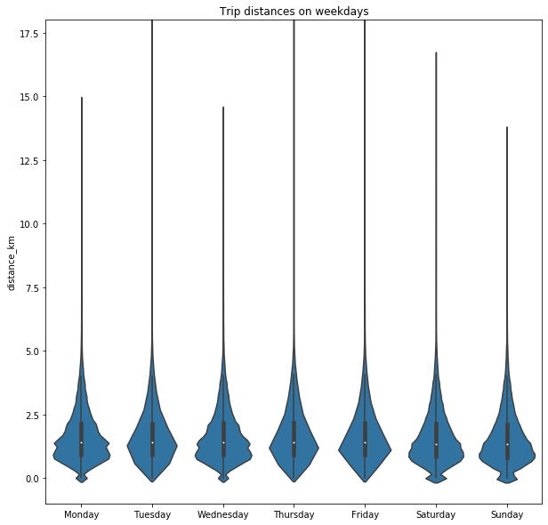

```python
plt.figure(figsize=[10, 10])
sns.violinplot(data = data, x = 'weekday', y='distance_km', color=base_color);
plt.xlabel('');
plt.ylim(-1, 18) # limited to exclude the outliers with very long trips
plt.title('Trip distances on weekdays');
```

### Regions

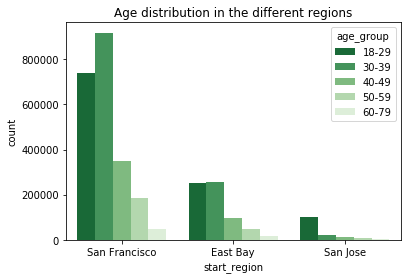

```python
# age distribution of the different regions
region_order = ['San Francisco', 'East Bay', 'San Jose']
sns.countplot(data = data, x = 'start_region', hue = 'age_group', hue_order = age_order, order = region_order, palette = 'Greens_r');
plt.title('Age distribution in the different regions');
```

The three regions differ in age distribution of the users. In San Francisco, the group of 30-39 years old has the most trips, wheras in East Bay, both the group of 18-29 years and 30-39 years have nearly equal amont of trips. In San José, the 18-29 group has much more trips than any other group.

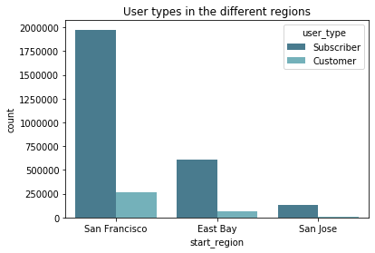

```python
# Distribution of user types in the regions
region_order = ['San Francisco', 'East Bay', 'San Jose']
user_order = ['Subscriber', 'Customer']
sns.countplot(data = data, x = 'start_region', hue = 'user_type', hue_order = user_order, order = region_order, palette = base_palette);
plt.title('User types in the different regions');
```

There seem to be no difference in user type distribution

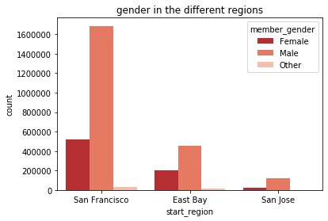

```python
#gender distributions in the regions
region_order = ['San Francisco', 'East Bay', 'San Jose']
sns.countplot(data = data, x = 'start_region', hue = 'member_gender', order = region_order, palette = 'Reds_r');
plt.title('gender in the different regions');
```

This shows that in East Bay, the proportion of females is higher than in the other regions.

### Talk about some of the relationships you observed in this part of the investigation. How did the feature(s) of interest vary with other features in the dataset?

- Exploring the time related trip counts revealed that bikes were differently used on working days and weekends. While on working days there is much more bike traffic on rush hour times, indicating that bikes were mostly hired for the way to work, the pattern changes on weekends to less counts but larger distributions around noon and early afternoon, probably the bikes were used for leisure or sports.

### Did you observe any interesting relationships between the other features (not the main feature(s) of interest)?

> Looking on the relationship of gender to the duration of trips showed, that women seem to take longer trips than men.

## Multivariate Exploration

#### hourly and daily usage patterns of customers and subscribers

> As seen above, customers and subscribers showed differences in their weekly and daily usage pattern. Also, generally hourly usage patterns differ with day of week. Thus it would be of interest to resolve these patterns by the user groups

```python
# split datframe in customer_data and subscriber_data
customer_data = data[data.user_type == 'Customer']
subscriber_data = data[data.user_type == 'Subscriber']

#calculating percentage of total  trips for  each group and pivoting data
customer_props = customer_data.groupby(['hour', 'weekday']).size()/customer_data.shape[0]*100
customer_props = customer_props.reset_index(name = 'count')
customer_props = customer_props.pivot(index = 'hour', columns = 'weekday', values = 'count')

subscriber_props = subscriber_data.groupby(['hour', 'weekday']).size()/subscriber_data.shape[0]*100
subscriber_props = subscriber_props.reset_index(name = 'count')
subscriber_props = subscriber_props.pivot(index = 'hour', columns = 'weekday', values = 'count')
```

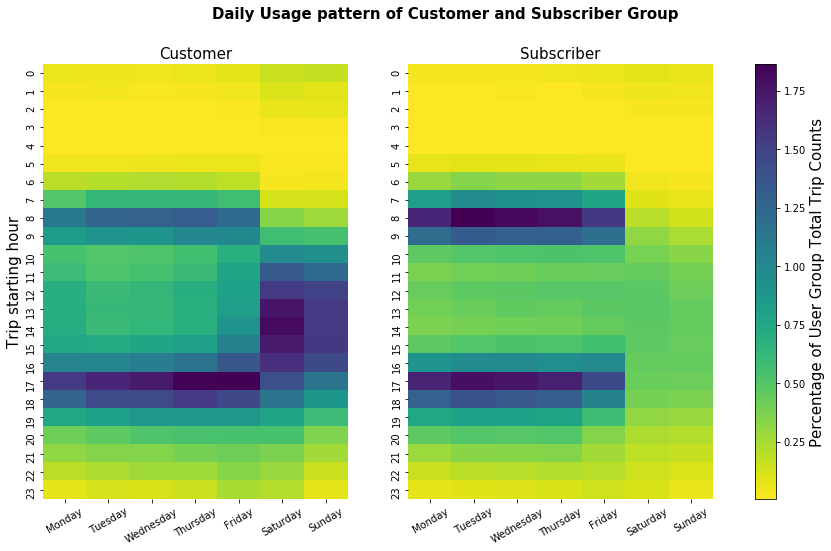

```python
fig, (ax1, ax2) = plt.subplots(1, 2, sharex=True,  figsize=[15,8])
plt.suptitle(t='Daily Usage pattern of Customer and Subscriber Group ', size=15, weight='bold')

# left plot
im = sns.heatmap(customer_props, ax=ax1,  cmap='viridis_r', cbar = False)
ax1.set_ylabel('')
ax1.set_xlabel('')
ax1.set_title(label='Customer', size=15)
ax1.tick_params(axis='x', rotation=30, )
ax1.set_ylabel(ylabel="Trip starting hour", size=15)

# right plot
sns.heatmap(subscriber_props, ax=ax2, cmap='viridis_r', cbar = False)
ax2.set_ylabel('')
ax2.set_xlabel('')
ax2.set_title(label='Subscriber', size=15)
ax2.tick_params(axis='x', rotation=30, )

# access and change colorbar
mappable = im.get_children()[0]
cbar = plt.colorbar(mappable, ax = [ax1,ax2] )
cbar.set_label(label='Percentage of User Group Total Trip Counts',size=15)



# https://stackoverflow.com/questions/45122416/one-horizontal-colorbar-for-seaborn-heatmaps-subplots-and-annot-issue-with-xtick
```

- we can clearly see that the group of subscribers is contributing most to the observed traffic during rush hours on weekdays.
- Customers also are very active at these times, but they also show much activity on weekends.
- so we can conclude that it is the group of subscribers that use the bikes mostly for work, while customers use them both, for work and for leisure times.

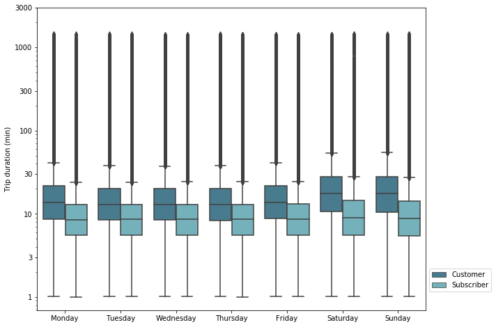

```python
plt.figure(figsize=[10,8])

g = sns.boxplot(data = data, x = 'weekday', y='duration_min', hue='user_type', palette=base_palette)
plt.yscale('log');
plt.xlabel('');
ylabels = [1, 3, 10, 30, 100, 300, 1000, 3000];
yticks = ylabels;
plt.yticks(yticks, ylabels);
plt.ylabel('Trip duration (min)');
g.legend(loc='center left', bbox_to_anchor=(1, 0.1), ncol=1);

# https://stackoverflow.com/questions/53733755/how-to-move-legend-to-outside-of-a-seaborn-scatterplot
```

- here we can clearly see that over all days of week the customer take longer trips than the subscriber
- the median trip duration of subscribers doesn't change over the week, whereas the median trip duration of the customer group is higher on weekends than on working days.
- this supports the findig that customers use the bikes also for leisure, maybe for longer trips or sports on weekends, whereas on working days there were more short trips probably directly to or from work

### Talk about some of the relationships you observed in this part of the investigation. Were there features that strengthened each other in terms of looking at your feature(s) of interest?

- In the heatmaps of the usage distribution separated for customers and subscribers we can see, that the bike usage seen on weekends comes more from the the customers, while in the rushours on working days both user types contribute to the seen peaking patterns.
- Summarizing the findings of trip duration and trip starting times pattern we can conclude that the subscriber group mostly takes the bike to go to and from work, while the customer group uses bikes for the way to and from work as well as for other purposes in free times.

### Were there any interesting or surprising interactions between features?

> It was surprising that not also the time usage but also the trip durations differences between the user types can be seen so clearly.

```python
# saving the final dataframe for later usage

data.to_csv('baywheels_data_final.csv', index=False)
```